# Selection and Demography

Population Genomics · PB 495/595 Plant Evolutionary Biology

George P. Tiley

8 September 2026

## Review

- The fundamental goal is estimating expected heterozygosity $H_e$ and determining if observed heterozygosity $H_o$ is different.
- New mutations arise at rate $\mu$ per site per generation, and the **effective population size** $N_e$ sets the strength of drift.
- There are different ways to estimate genetic variation such as $\pi$ and $\theta_W$, which do not always agree.
- Sometimes, population structure and non-selective forces cause differences between expected and observed variation, and our various estimators.

## Learning objectives

- Convince ourselves that $\pi = \theta_W = \theta = 4N_e\mu$ under **neutrality** and a constant $N_e$.
- Derive and interpret **Tajima’s $D$**, interpret its sign.
- Build the **site frequency spectrum (SFS)** from a sample and state its **neutral expectation** $\mathbb E[\xi_i]=\theta/i$.
- Explain why **demography is genome-wide** but **selection is local** and how that can be useful in practice.
- Describe **linked selection** in the form of **selective sweeps** and **background selection**.

## Motivation from sweetpotato

The progitors of modern sweetpotato (*Ipomoea batatas*) are still a topic of debate and great interest remains in understanding genetic diversity in this crop and its wild relatives.

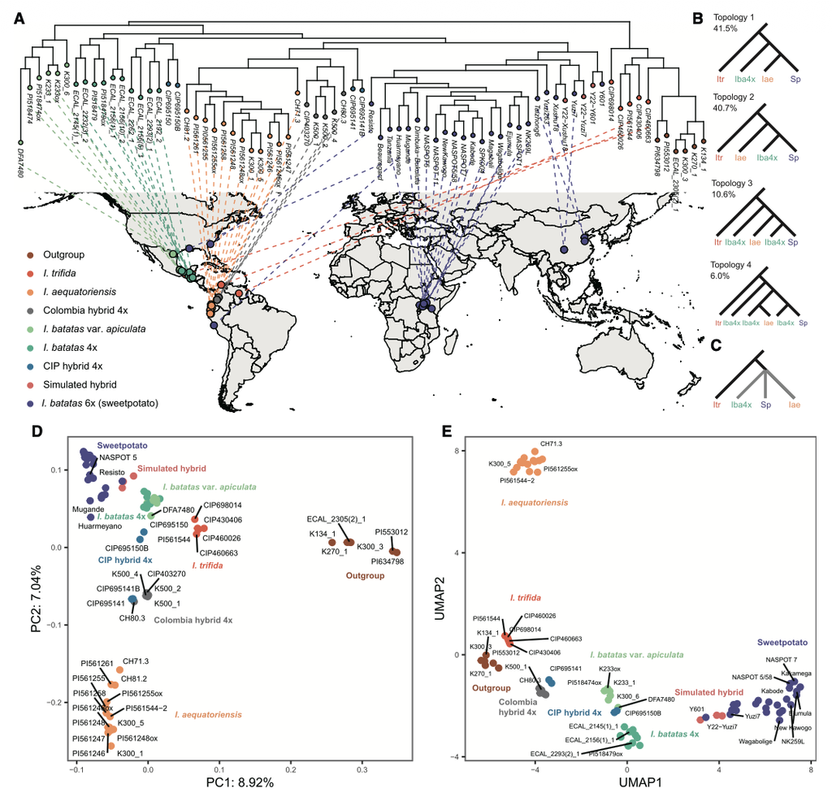

Global structure and diversity across sweetpotato and close relatives Yan et al. (2024)

## Motivation from sweetpotato

Why? The genetic basis of traits!

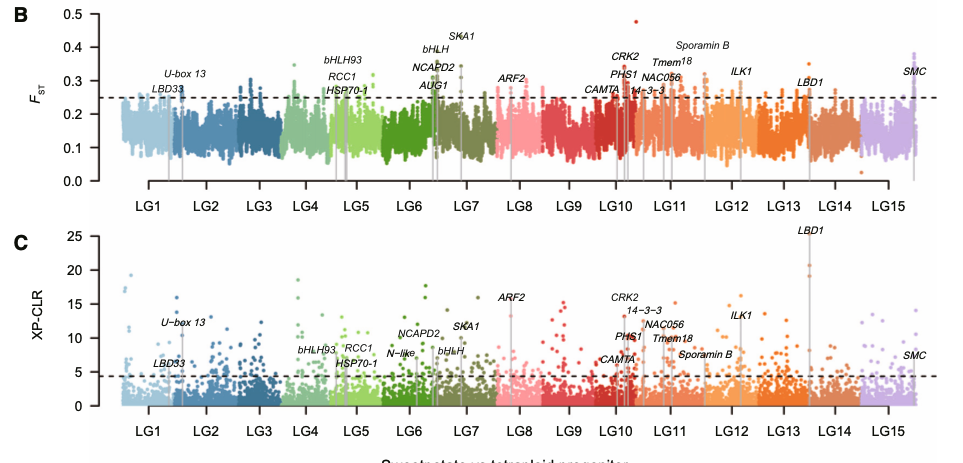

Selection scans across the genome relative to potential diploid ancestors Yan et al. (2024)

## Moving from the modern synthesis to **neutral theory** and the **coalescent**

- **Modern synthesis**: evolution is driven by **selection** on **phenotypes**. Prior to molecular data.
- **Neutral theory**: most evolutionary change at the molecular level is due to **genetic drift** of **neutral mutations**.
- **Coalescent theory**: a model to develop expectations for genetic variation consistent with neutral theory.

[figure not shown]

Foundational scientists to modern thinking on selection versus stochastic processes in molecular evolution

## Core results from neutral theory

$$\theta = 4N_e\mu$$

Where $\theta$ is the expected number of differences (per site) between two sequences sampled from the population. $N_e$ is the effective population size, and $\mu$ is the mutation rate per site per generation. The 4 sneaks in because we are considering **diploid** organisms. If we had a haploid population, the equation would be $\theta = 2N_e\mu$.

$\pi$ is an **estimator** of $\theta$ based on pairwise differences.

$\theta_W$ is an **estimator** of $\theta$ based on the number of segregating sites.

## Core results from neutral theory

We often try to distinguish mutations from substitutions. A **mutation** is a change in the DNA sequence that occurs in an individual, while a **substitution** is a mutation that has become fixed in a population.

The neutral theory predicts that the **substitution rate** $\rho$ is equal to the **mutation rate** $\mu$ and is **independent of population size**.

Let $\mu$ be the mutation rate per site per generation, then the average number of new mutations per generation is $2N\mu$ in a diploid population.

The probability that a new mutation fixes is $1/(2N)$ - we are ignoring selection and assuming all mutations have and equally likely chance of not drifting to extinction.

So the substitution rate is:

$$\rho = 2N\mu \times \frac{1}{2N} = \mu$$

# The coalescent for a single population

## A sample in the present

A sample of **10 individuals** in the present, $t_0$.

Time runs **left to right, into the past**.

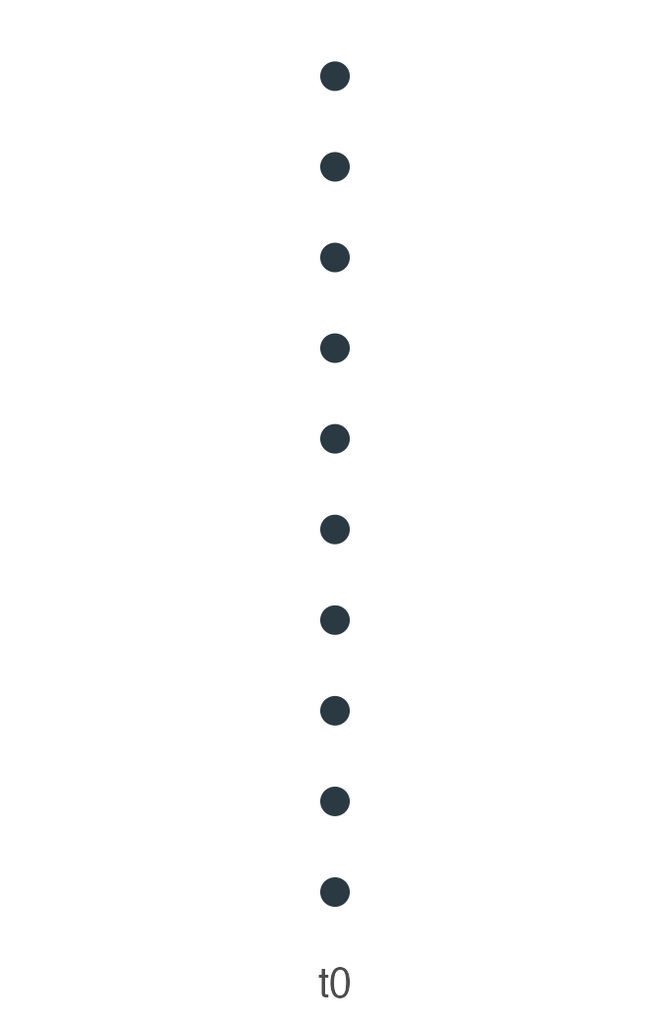

## One generation back

Each individual draws a parent **uniformly at random** from the previous generation, independently of every other individual.

This generational sampling assumption is the **Wright-Fisher model**. It would be appropriate for a monoecious annual plant population.

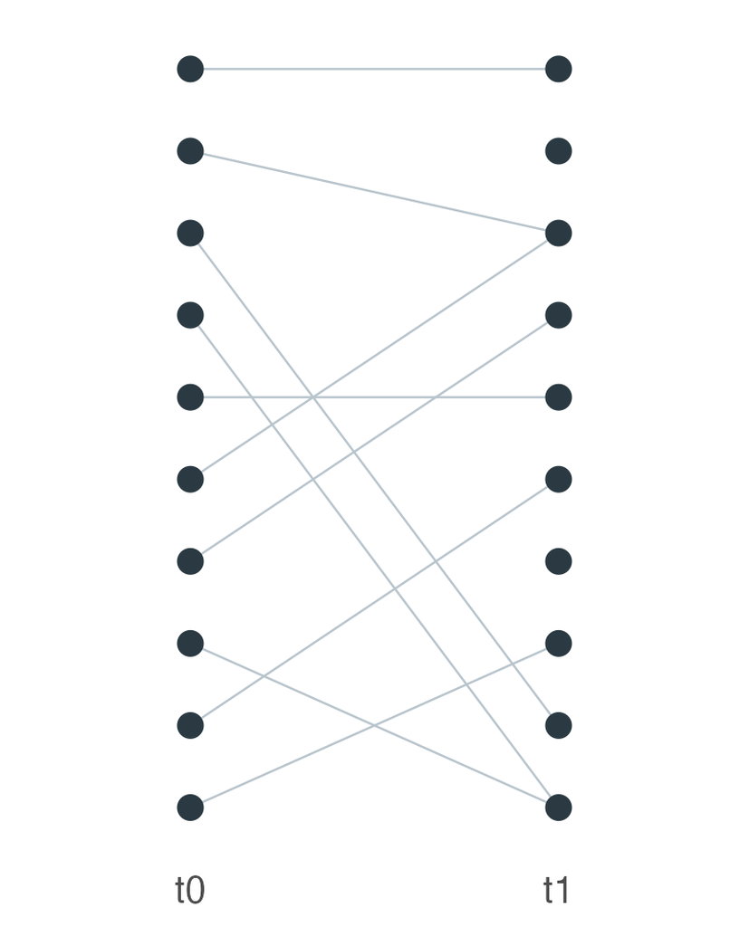

## Two alleles that share a parent

$$P(\text{share an ancestor 1 generation ago}) = \frac{1}{2N}$$

The first allele picks some parent; the second picks the **same** one with probability $1/2N$.

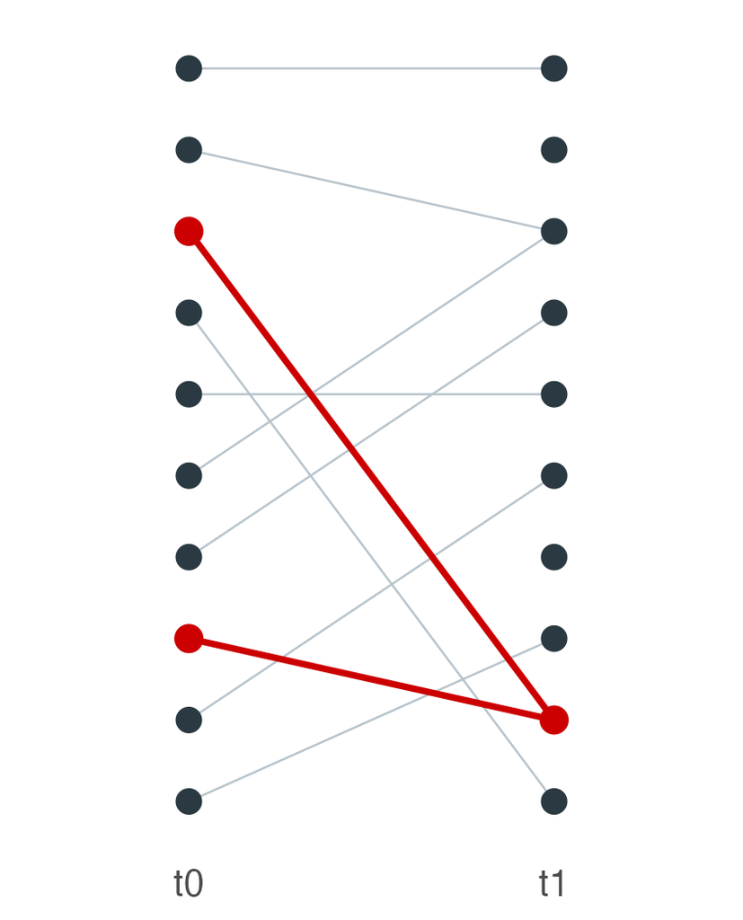

## Two alleles that do not

$$P(\text{do not share an ancestor}) = 1 - \frac{1}{2N}$$

## Following two lineages back

## Waiting for the first coalescence

$P(\text{two alleles coalesce in generation } i \mid N)$

$$P(t=i) = \left( 1 - \frac{1}{2N} \right)^{i-1}\left( \frac{1}{2N} \right)$$

## That is a geometric distribution

Geometric with $p = 1/2N$:

$$P(t \mid N) = \left( 1 - \frac{1}{2N} \right)^{i-1}\left( \frac{1}{2N} \right)$$

$$\boxed{\;\mathbb{E}[t] = \frac{1}{p} = 2N\;}$$

## Not coalescing for a while

$P(\text{two alleles do not coalesce in } i \text{ generations})$

$$P(t > i) = \left( 1 - \frac{1}{2N} \right)^{i}$$

## An exponential approximation

$$P(t > i) = \left( 1 - \frac{1}{2N} \right)^{i}$$

Since $\left( 1 - \frac{1}{2N} \right) \approx e^{-\frac{1}{2N}}$,

$$P(t > i) \approx e^{-\frac{i}{2N}}$$

## Rescaling time

$$P(t > i) \approx e^{-\frac{i}{2N}} \approx e^{-T}$$

Measuring time in units of $2N$ generations removes $N$ from the expression entirely.

## Coalescent units

$$P(t > i) \approx e^{-T}$$

$$T = \frac{\text{number of generations}}{2N}$$

One coalescent unit $=2N$ generations.

# What about more than two alleles?

## More than two alleles

Everything so far followed a **pair**. A real sample has $n$ lineages, and any pair of them can coalesce.

## One lineage

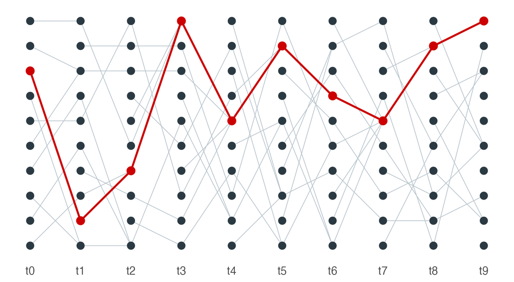

## Two lineages

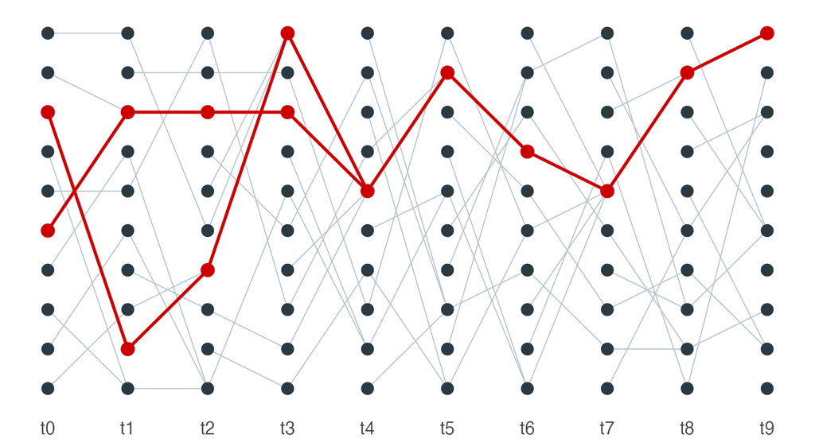

## Three lineages

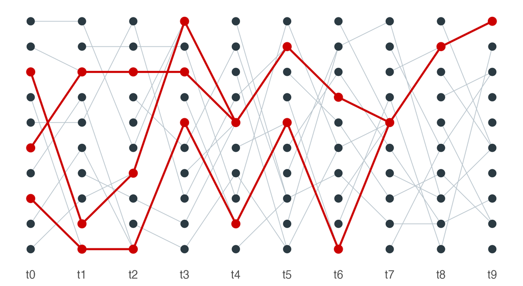

## Three alleles, one generation

$P(\text{3 alleles do not coalesce in 1 generation})$

$$= \left( 1 - \frac{1}{2N} \right) \times \left( 1 - \frac{2}{2N} \right)$$

The second lineage must miss the first; the third must miss **both**.

## Two alleles

$P(\text{2 alleles do not coalesce in 1 generation})$

$$= 1 - \frac{1}{2N}$$

## Three alleles

$P(\text{3 alleles do not coalesce in 1 generation})$

$$= \left( 1 - \frac{1}{2N} \right) \times \left( 1 - \frac{2}{2N} \right)$$

## $n$ alleles

$P(n \text{ alleles do not coalesce in 1 generation})$

$$= \left( 1 - \frac{1}{2N} \right) \times \left( 1 - \frac{2}{2N} \right) \times \cdots \times \left( 1 - \frac{n-1}{2N} \right)$$

## Dropping the small terms

Expanding the product leaves terms that look like $1/N$ terms that have $1/N^2$. Because we expect $n \ll N$, we can drop the terms that have $1/N^2$ from the expansion.

$$1 - \sum_{i=1}^{n-1}\frac{i}{2N} + \sum_{i<j}\frac{i}{2N}\cdot\frac{j}{2N} - \cdots$$

$$\approx 1 - \frac{1 + 2 + \cdots + (n-1)}{2N}$$

## The complement

$$P(n \text{ alleles do}) = 1 - P(n \text{ alleles do not})$$

$$= \frac{1 + 2 + \cdots + (n-1)}{2N}$$

## Summing the series

Since $1 + 2 + \cdots + (n-1) = \frac{n(n-1)}{2}$,

$$P(n \text{ alleles do}) = \frac{n(n-1)}{4N}$$

## Waiting time for $n$ alleles

$P(n \text{ alleles coalesce in the } i\text{th generation})$

$$= \left[ 1 - \frac{n(n-1)}{4N} \right]^{i-1} \frac{n(n-1)}{4N}$$

## Geometric again

The same geometric form, so the expectation is the reciprocal of the success probability:

$$\boxed{\;\mathbb{E}[t] = \frac{4N}{n(n-1)}\;}$$

## The combinatoric form

$\frac{n(n-1)}{2}$ is the number of **pairs**, so the same result reads:

$$= \left[ 1 - \binom{n}{2}\left( \frac{1}{2N} \right) \right]^{i-1} \binom{n}{2}\frac{1}{2N}$$

Each of the $\binom{n}{2}$ pairs coalesces at rate $1/2N$.

## Expectation, combinatoric form

$$\mathbb{E}[t] = \frac{2N}{\binom{n}{2}}$$

Identical to $4N/n(n-1)$ — the pair-counting view just makes the mechanism explicit.

## To continuous time

As before, the geometric waiting time is well approximated by an **exponential** once $N$ is large.

## The per-pair rate

A single pair coalesces at rate

$$T = \frac{1}{2N}$$

per generation.

## Counting the ways

There are $n-1$ coalescent events to get from $n$ lineages to one, and $\binom{n}{2}$ ways for the next one to happen.

## The $j$th coalescence

With $\binom{j}{2} = \frac{j(j-1)}{2}$ pairs available when $j$ lineages remain:

$$f(T_j) = \frac{j(j-1)}{2}\exp\left\{ -\frac{j(j-1)}{2}T_j \right\}$$

## All coalescences on a genealogy $G$

The intervals are independent, so the density of the whole set of waiting times is a product:

$$f(T \mid G) = \prod_{j=2}^{n} \frac{j(j-1)}{2}\exp\left\{ -\frac{j(j-1)}{2}T_j \right\}$$

## Expectations for the TMRCA

Each interval is exponential, so its expectation is the reciprocal of its rate:

$$\mathbb{E}[T_j] = \frac{2}{j(j-1)}$$

and the time to the most recent common ancestor is the sum of the intervals:

$$\mathbb{E}[T_{MRCA}] = \mathbb{E}(T_n + T_{n-1} + \cdots + T_2)$$

## Collapsing the sum

$$\mathbb{E}[T_{MRCA}] = \sum_{j=2}^{n} \frac{2}{j(j-1)} = 2\sum_{j=2}^{n}\left( \frac{1}{j-1} - \frac{1}{j} \right)$$

The sum telescopes:

$$\mathbb{E}[T_{MRCA}] = 2\left( 1 - \frac{1}{n} \right) \approx 2 \;\text{ coalescent units } = 4N \text{ generations}$$

## Important conclusion

$\mathbb{E}[T_{MRCA}] converges to 2$ coalescent units as $n$ grows

This means that adding more samples does not add much information about deeper coalescent events. Ten lineages should already capture $2(1-1/10)=1.8$ of the maximum 2.

# Watterson’s $\theta$

## From waiting times to branch length

So far we have the **depth** of the tree. That can be useful for estimating split times for speciation later on, but for now we only care about counting segregating sites. They occur on **branches**, so what we need is total branch length.

While $j$ lineages remain, there are $j$ branches accumulating length, each for a duration $T_j$. So

$$\mathbb{E}[L] = \sum_{j=2}^{n} j \; \mathbb{E}[T_j]$$

This takes the form of the nth coalescent before.

## The sum collapses again

Substituting $\mathbb{E}[T_j] = \dfrac{4N}{j(j-1)}$ generations:

$$\mathbb{E}[L] = \sum_{j=2}^{n} j \times \frac{4N}{j(j-1)}
= 4N\sum_{j=2}^{n} \frac{1}{j-1}
= 4N\sum_{i=1}^{n-1} \frac{1}{i}$$

$$\boxed{\;\mathbb{E}[L] = 4N a_n, \qquad a_n = \sum_{i=1}^{n-1}\frac{1}{i}\;}$$

The $j$ in the numerator cancels the $j$ in $j(j-1)$ — more lineages means more branches, but proportionally shorter intervals.

## $a_n$ grows like $\log n$

- Here $n$ is logarithmic on the x axis, $a_n$ is linear on the y axis.
- Going from $n=2$ to $n=10$ nearly **triples** the tree length.
- Going from $n=10$ to $n=200$ — twenty times the sequencing — only **doubles** it.

Thus, we do not emphasize sampling many individuals within a population.

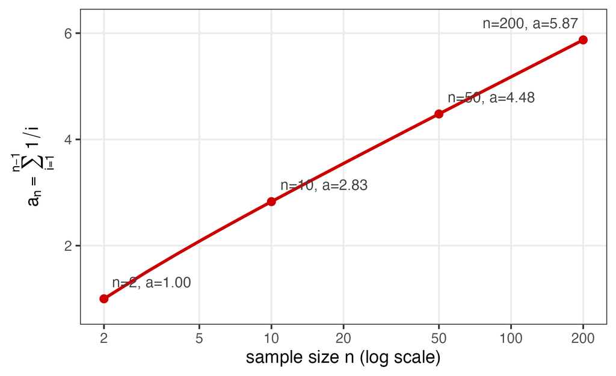

## Mutations land on the tree

Under the infinite-sites model, mutations arrive along branches at rate $\mu$ per generation, independently of the genealogy.

So the number of **segregating sites** is just a thinned version of the total branch length:

$$\mathbb{E}[S] = \mu\,\mathbb{E}[L] = 4N\mu\,a_n$$

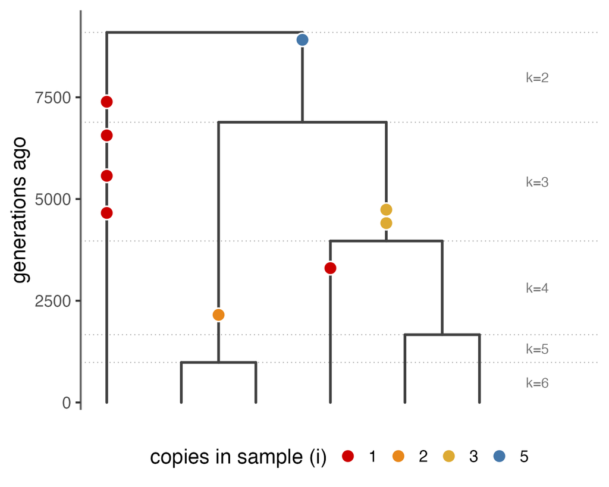

## The definition of $\theta$

Writing $\theta = 4N\mu$, the population mutation parameter:

$$\boxed{\;\mathbb{E}[S] = \theta\,a_n\;}$$

$\theta$ compounds mutation and population size. A large population mutating slowly and a small population mutating fast produce the same spectrum of variation. Your organismal expertise is needed to separate the two.

## Watterson’s estimator

Rearranging $\mathbb{E}[S] = \theta a_n$ gives an estimator you can compute from a sequence alignment (Watterson 1975):

$$\boxed{\;\hat\theta_W = \frac{S}{a_n}\;}$$

- **Unbiased** by construction: $\mathbb{E}[\hat\theta_W] = \theta$.
- Needs only $S$, the count of variable sites, and $n$.
- Per site, divide by sequence length.

# The site frequency spectrum

## Definition and neutral expectation

The **SFS** counts segregating sites by the number of copies $i$ of the derived allele in a sample of $n$. Under the neutral, constant-size coalescent:

$$\boxed{\;\mathbb E[\xi_i] = \frac{\theta}{i}, \qquad i = 1, \dots, n-1\;}$$

- A mutation on a branch subtending $i$ tips appears $i$ times
- rare variants (singletons, $i=1$) *should* dominate the SFS
- $\pi$ and $\theta_W$ are different summary statistics from the same SFS: $\theta_W \propto \sum_i \xi_i$ (counts sites equally), $\pi \propto \sum_i i(n-i)\,\xi_i$ (weights intermediate frequencies).

## Definition and neutral expectation

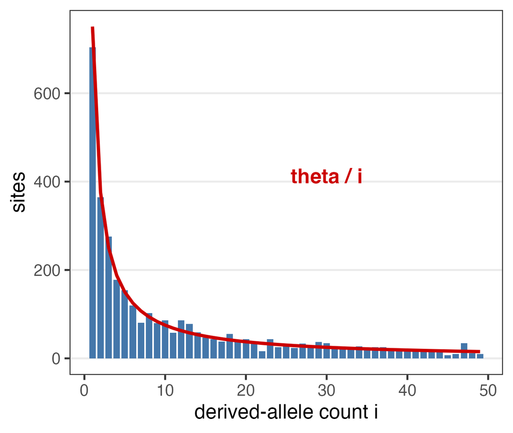

Simulated: $n=50$, 2 Mb, constant $N_e=10^4$

## Folded vs. unfolded

- **Unfolded** SFS needs an **outgroup** to polarize ancestral vs. derived (often difficult in practice).
- **Folded** SFS uses the **minor**-allele count $\eta_i = \xi_i + \xi_{n-i}$

A complication of the unfolded SFS is that errors in **polarization** can create a heavy tail, which looks like a historical bottleneck or a completed selective sweep.

## Polarization errors in action

- Introduce **25%** polarization error and the **unfolded** spectrum grows a fake high-frequency-derived tail.
- The **folded** spectrum is unchanged in both panels.

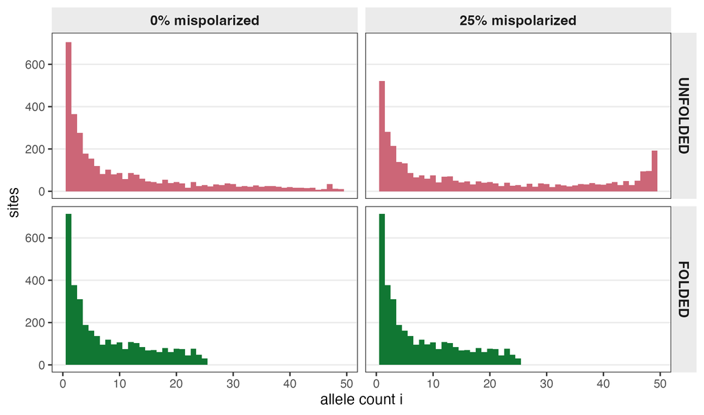

# Tajima’s $D$

## Construction

Both $\pi$ and $\theta_W$ estimate $\theta$, so their **difference** reflects when evolution deviates from neutrality. Tajima (Tajima 1989) derived the standardization constant that allows the difference to be interpreted as a **Z-score**, where anything less than about $-2$ or greater than about $+2$ is a significant departure from neutrality:

$$D = \frac{\pi - \theta_W}{\sqrt{\widehat{\mathrm{Var}}(\pi - \theta_W)}} .$$

- $\pi$ is affected most by **intermediate**-frequency variants; $\theta_W$ counts **all** segregating sites.
- So Tajima’s $D$ asks: is the SFS skewed towards rare variants ($\pi < \theta_W$) or intermediate variants ($\pi > \theta_W$)?

## Interpreting the sign

| $D$ | SFS shape | Demographic cause (genome-wide) | Selective cause (local) |
| --- | --- | --- | --- |
| $< 0$ | excess rare variants | expansion — **or a bottleneck it has recovered from** | recent **sweep**, purifying selection |
| $\approx 0$ | neutral | constant size | neutral |
| $> 0$ | excess intermediate | a contraction you are **still inside**, structure | **balancing** selection |

## “Bottleneck” is not one signature

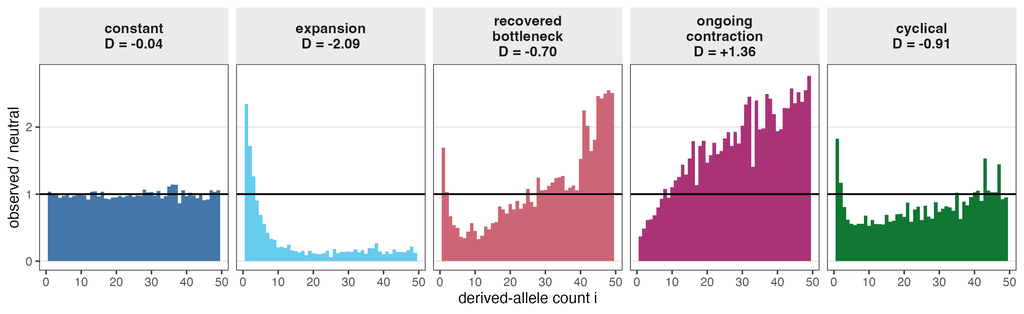

20 replicates each; $n=50$, 2 Mb.

- **Expansion** and **recovered bottleneck** both give $D<0$ — one population grew, the other crashed. Backwards from the present, a recovery *is* an expansion.
- Only the **ongoing contraction** — still sitting at $N_e/10$ — gives $D>0$.
- The sign of $D$ reports the **recent direction of change in $N_e$**, not whether a bottleneck ever happened.
- Note the spread, too: the recovered bottleneck has $\text{sd}(D)=0.60$ vs $0.09$ for the expansion. A crash is a **randomizing** event — replicate genomes disagree.

## Demography vs. Selection

- **Demography** (bottlenecks, expansions, structure) acts on **every locus** — it shifts the **genome-wide** SFS.
- **Selection** acts on **specific loci** and their linked neighborhoods — a **local** departure against the genome-wide background.
- ⟹ Build the **genome-wide distribution** of $D$ (or $F_{ST}$), then flag **outliers**.

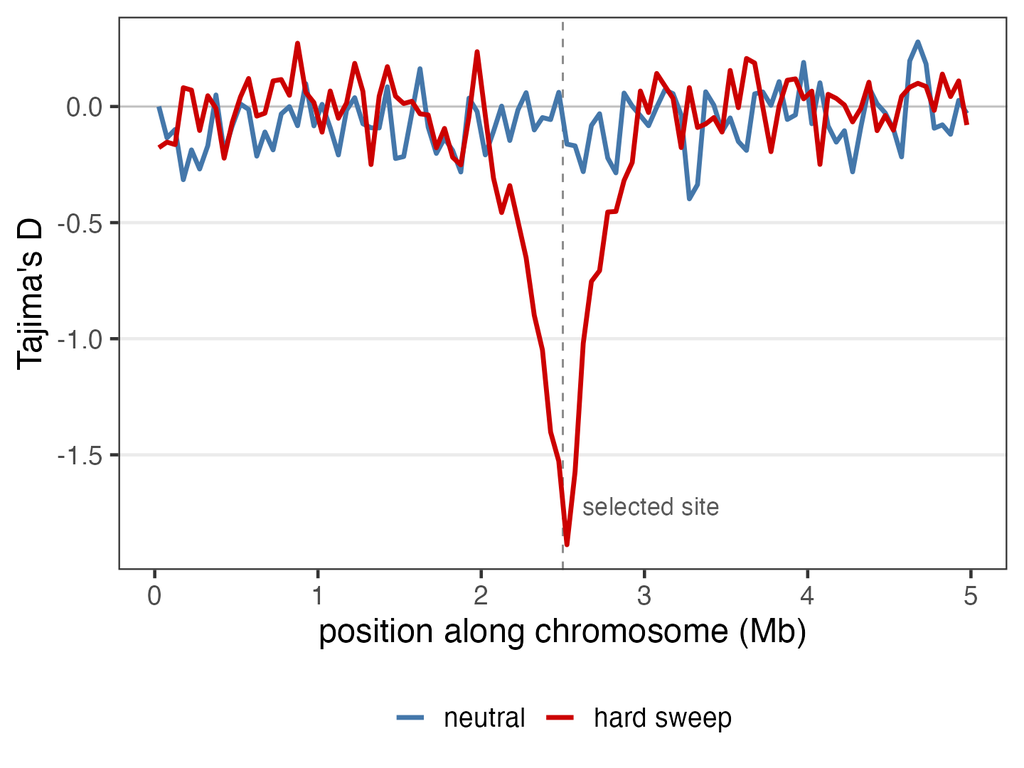

30 replicates, 50 kb windows, $s=0.05$. Both lines are the *same* demography — only the sweep differs.

## Examples from corn domestication

Maize was domesticated from **teosinte** ~9,000 years ago through a **bottleneck** (Wright et al. 2005; Hufford et al. 2012):

- **Genome-wide:** the bottleneck lost diversity and skewed the SFS — a demographic signature present everywhere.
- **At domestication loci** (e.g. *tb1*, *teosinte branched1*): a **selective sweep** drove a far stronger **local** loss of diversity and strongly **negative** $D$, standing out above the genome-wide background.

## Examples from corn domestication

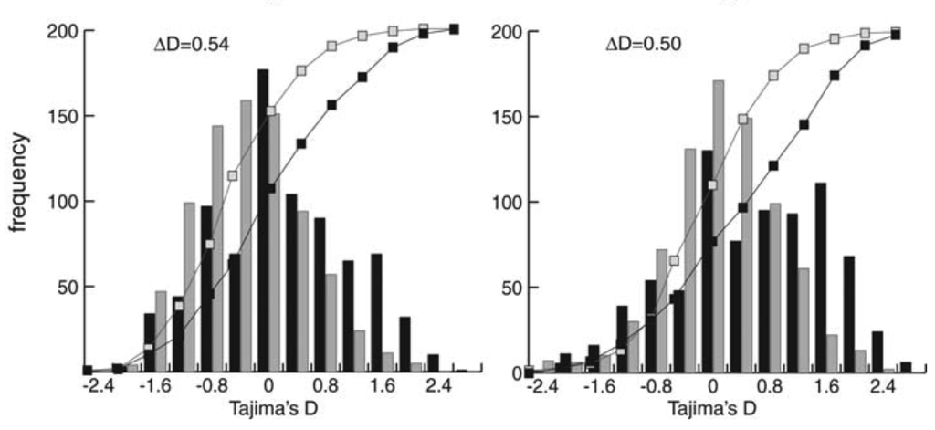

Significant evidence for a bottleneck in the history of corn domestication from Tajima’s $D$ from Wright et al. (2005)

## Examples from corn domestication

Do you expect more rare variants or intermediate variants based on this tree?

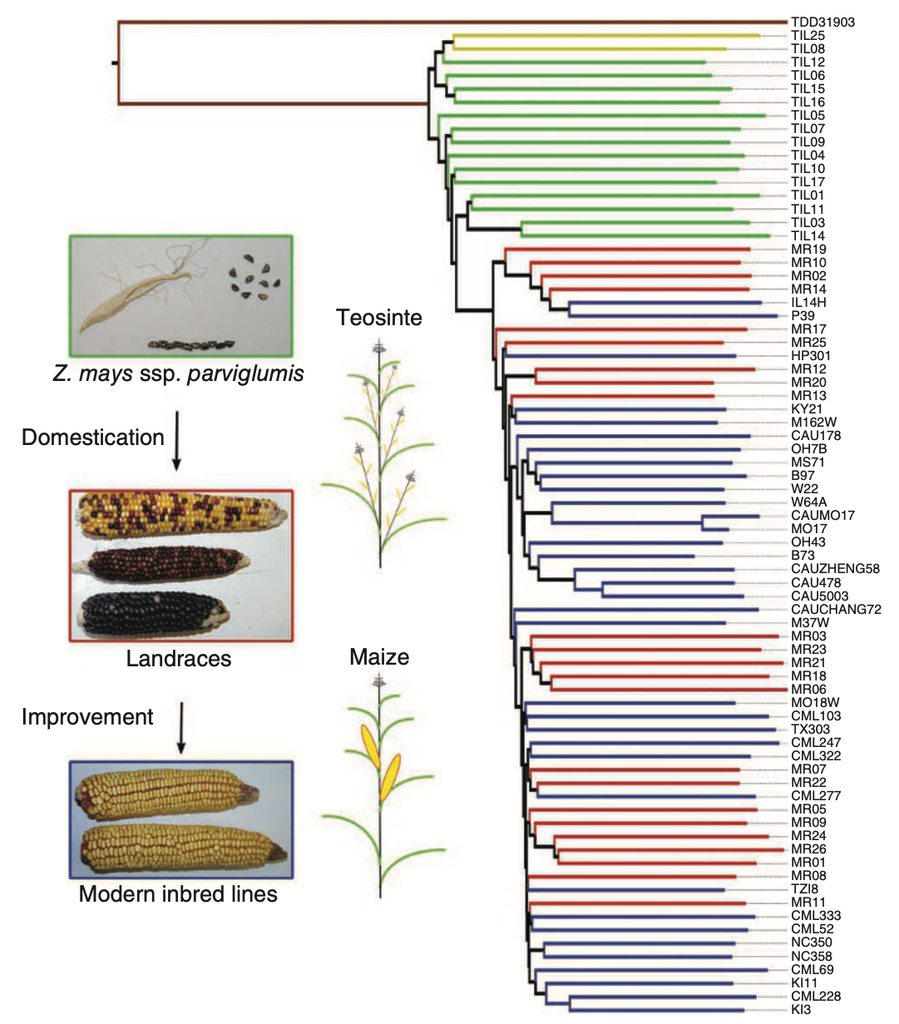

Neighbor joining tree of maize and teosinte from Hufford et al. (2012)

## Examples from corn domestication

Signatures of selection recognizable from multiple lines of evidence:

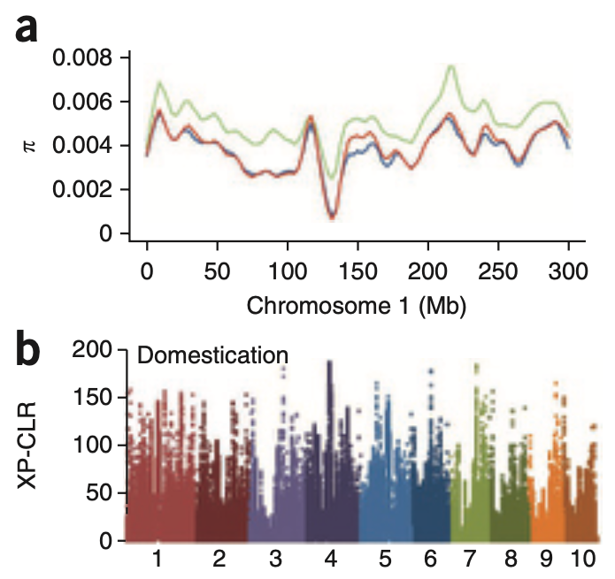

Sweep for domestication loci on chromosomes one from Hufford et al. (2012)

# Linked selection

## Selection drags its neighbors

Selection acts on one site, but **linkage** spreads the consequences to neutral neighbors — the dominant force shaping diversity *along* a genome.

- **Selective sweep (hitchhiking):** a favored mutation sweeps to fixation, dragging its haplotype and **erasing** nearby diversity — a **valley** in $\pi$ (Maynard Smith and Haigh 1974).
- **Background selection:** purging of linked **deleterious** mutations also removes neutral variation, depressing diversity in low-recombination regions (Charlesworth, Morgan, and Charlesworth 1993).

## How deep and how wide?

$T_{\text{fix}}$ is the number of generations for a new beneficial allele to sweep from a single copy to fixation. $c$ is the **recombination rate** — the probability per generation of a crossover between the selected site and a neutral neighbor.

$$T_{\text{fix}} \approx \frac{2\ln(2N_e)}{s},
\qquad
\text{swept width} \sim \frac{s}{c}.$$

- Stronger selection $s$ ⟹ faster fixation ⟹ **deeper** valley (less time for recombination to rescue neutral variants).
- More recombination $c$ ⟹ **narrower** valley (neighbors escape the sweep).
- Diversity **recovers** with time $T$ after the sweep.

## How deep and how wide?

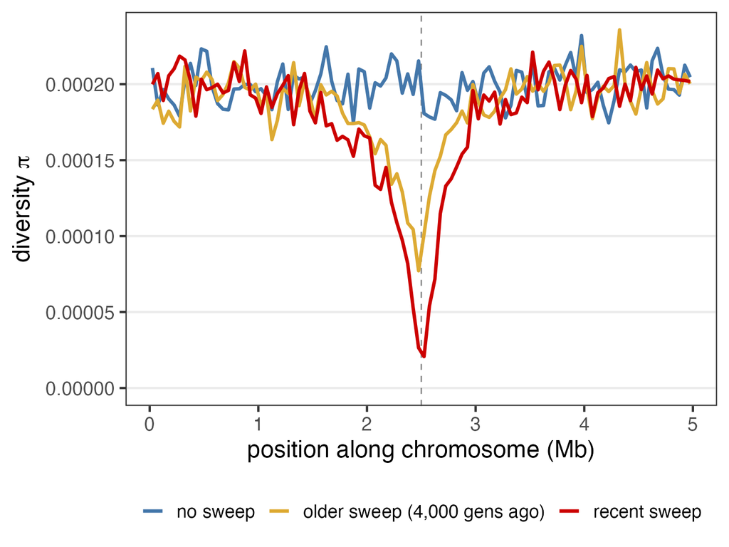

## Hard, soft, and partial sweeps

- **Hard sweep** — a *single* new mutation fixes; one haplotype dominates. This is the strongest signal but kind of rare for natural plant populations.
- **Soft sweep** — selection on **standing variation** or recurrent mutation. Multiple haplotypes can carry the adaptive allele and the variation around the target makes a *softer* peak.
- **Partial sweep** — there is an adaptive allele but it remains at an intermediate frequency and does not reach fixation.

## Computing Tajima’s $D$ from an SFS

The sweep signature is an SFS skewed to **rare** variants. Compute $D$ directly from a folded/unfolded spectrum:

```r
TajimaD <- function(sfs) {              # sfs = c(#singletons, #doubletons, ...)
  n  <- length(sfs) + 1                 # number of sampled chromosomes
  ss <- sum(sfs)                        # segregating sites
  a1 <- sum(1 / seq_len(n - 1)); a2 <- sum(1 / seq_len(n - 1)^2)
  b1 <- (n + 1) / (3 * (n - 1)); b2 <- 2 * (n^2 + n + 3) / (9 * n * (n - 1))
  c1 <- b1 - 1/a1; c2 <- b2 - (n + 2)/(a1 * n) + a2/a1^2
  e1 <- c1 / a1;  e2 <- c2 / (a1^2 + a2)
  theta_pi <- sum(sapply(seq_along(sfs), function(i) i*(n-i)*sfs[i])) / choose(n, 2)
  theta_w  <- ss / a1
  (theta_pi - theta_w) / sqrt(e1*ss + e2*ss*(ss-1))
}
```

## Sweep vs. neutral — try it

```r
sweep   <- c(20, 2, 1, 1, 1)   # rare-variant excess  → D < 0
neutral <- c( 6, 1, 2, 2, 4)   # flatter spectrum     → D ≈ 0
TajimaD(sweep)     # strongly negative
TajimaD(neutral)   # near zero
```

- The **sweep** SFS piles up singletons ⟹ $\pi \ll \theta_W$ ⟹ **negative** $D$.
- Change the counts and watch $D$ move — this is the engine behind the genome scans in deck 05.

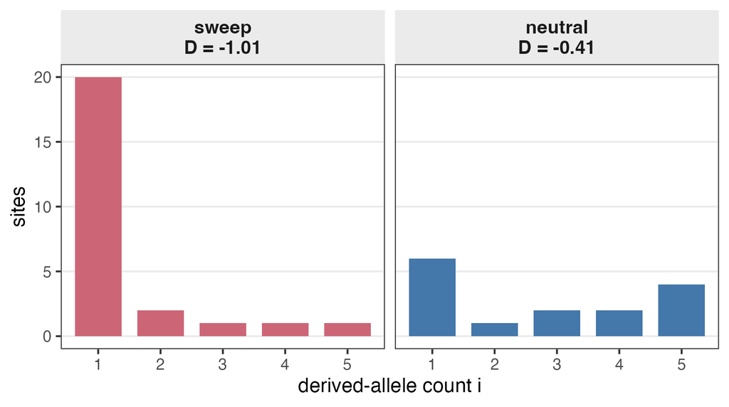

# Key takeaways

## Summary — key equations

$$\theta = 4N_e\mu
\qquad
\mathbb E[\xi_i] = \frac{\theta}{i}
\qquad
D = \frac{\pi - \theta_W}{\sqrt{\widehat{\mathrm{Var}}(\pi - \theta_W)}}
\qquad
T_{\text{fix}} \approx \frac{2\ln(2N_e)}{s}$$

## Summary - Review questions

- Under what conditions does $\pi = \theta_W = \theta = 4N_e\mu$?
- What does $\theta_W$ depend on?
- What does **Tajima’s $D$** tell us about the skew of the SFS?
- What is a potential risk of the **unfolded SFS**?
- What are demographic scenarios where Tajima’s $D$ has difficulty distinguishing between them?
- How can you differentiate demographic effects from selection?
- **Linked selection** can affect upstream and downstream diversity, but what affects the width and depth of the affected region?

# References

Charlesworth, Brian, M. T. Morgan, and Deborah Charlesworth. 1993. “The Effect of Deleterious Mutations on Neutral Molecular Variation.” *Genetics* 134 (4): 1289–1303. https://doi.org/10.1093/genetics/134.4.1289.

Hufford, Matthew B. et al. 2012. “Comparative Population Genomics of Maize Domestication and Improvement.” *Nature Genetics* 44 (7): 808–11. https://doi.org/10.1038/ng.2309.

Maynard Smith, John, and John Haigh. 1974. “The Hitch-Hiking Effect of a Favourable Gene.” *Genetical Research* 23 (1): 23–35. https://doi.org/10.1017/S0016672300014634.

Tajima, Fumio. 1989. “Statistical Method for Testing the Neutral Mutation Hypothesis by DNA Polymorphism.” *Genetics* 123 (3): 585–95. https://doi.org/10.1093/genetics/123.3.585.

Watterson, G. A. 1975. “On the Number of Segregating Sites in Genetical Models Without Recombination.” *Theoretical Population Biology* 7 (2): 256–76. https://doi.org/10.1016/0040-5809(75)90020-9.

Wright, Stephen I., Irie Vroh Bi, Steve G. Schroeder, Masanori Yamasaki, John F. Doebley, Michael D. McMullen, and Brandon S. Gaut. 2005. “The Effects of Artificial Selection on the Maize Genome.” *Science* 308 (5726): 1310–14. https://doi.org/10.1126/science.1107891.

Yan, Mengxiao, Ming Li, Yunze Wang, Xinyi Wang, M-Hossein Moeinzadeh, Dora G Quispe-Huamanquispe, Weijuan Fan, et al. 2024. “Haplotype-Based Phylogenetic Analysis and Population Genomics Uncover the Origin and Domestication of Sweetpotato.” *Molecular Plant* 17 (2): 277–96.